# Virginia Math Bulletin

### Christina Dawn Osborne: Decomposing the Classifying Diagram in Terms of Classifying Spaces of Groups

*Advisor: Julie Bergner*

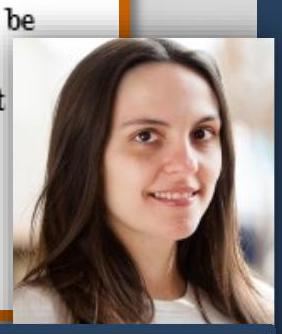

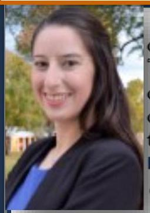

A topological space can be built from a category using the machinery of the nerve, which takes objects in the category to points and chains of $n$-composable morphisms to $n$-cells. The resulting space is referred to as the "classifying space" of the category. In particular, a group $G$ is a category with one object; $BG$ denotes its classifying space. However, two categories that are not equivalent can produce equivalent classifying spaces. The classifying diagram, defined in [2], is a generalization of the nerve. Two categories are equivalent if and only if their classifying diagrams are equivalent [1].

**Definition 3** ([2]). The classifying diagram of a category $\mathcal{C}$ is denoted by $N\mathcal{C}$ and is the simplicial space defined levelwise by
$$(N\mathcal{C})_{n}:=\operatorname{nerve}\left(\operatorname{iso}\left(\mathcal{C}^{[n]}\right)\right) .$$

The purpose of this thesis is to provide a deeper understanding of the classifying diagram by providing levelwise characterizations using classifying spaces of groups. Let $(x)$ denote the isomorphism class for $x \in \operatorname{ob}(\mathcal{C})$. It was already shown that $N(\mathcal{C})_{0} \simeq \coprod_{(x)} B\operatorname{Aut}(x)$ [1]. We provide a new characterization of the higher levels of the classifying diagram.
**Notation.** Let $\underline{x}=\left(x_{0}, \ldots, x_{n}\right)$ denote an $(n+1)$-tuple of objects in $\mathcal{C}$. We define a group action
$$\bullet : \operatorname{Aut}(\underline{x}) \times \operatorname{Hom}(\underline{x}) \rightarrow \operatorname{Hom}(\underline{x})$$
where $\operatorname{Aut}(\underline{x})$ denotes the group $\operatorname{Aut}\left(x_{0}\right) \times \operatorname{Aut}\left(x_{1}\right) \times \cdots \times \operatorname{Aut}\left(x_{n}\right)$ and $\operatorname{Hom}(\underline{x})$ denotes the set
$\operatorname{Hom}_{\mathcal{C}}\left(x_{0}, x_{1}\right) \times \operatorname{Hom}_{\mathcal{C}}\left(x_{1}, x_{2}\right) \times \cdots \times \operatorname{Hom}_{\mathcal{C}}\left(x_{n-1}, x_{n}\right)$

**Theorem 9**. Let $\left(f_{1}, \ldots, f_{n}\right)$ denote the equivalence class of $\left(f_{1}, \ldots, f_{n}\right) \in \operatorname{Hom}(\underline{x})$ defined by the group action $\bullet$. Then for $n \geq 1$,
$$N(\mathcal{C})_{n} \simeq \coprod_{\left(f_{1}, \ldots, f_{n}\right)} B\left[\operatorname{Aut}(\underline{x})_{\left(f_{1}, \ldots, f_{n}\right)}\right]$$
where $\operatorname{Aut}(\underline{x})_{\left(f_{1}, \ldots, f_{n}\right)}$ is the stabilizer of $\left(f_{1}, \ldots, f_{n}\right)$.

We use the above result and prove explicit decompositions of the classifying diagrams for the categories of finite ordered sets, finite-dimensional vector spaces, and finite sets.

#### References

[1] J. Bergner, The Homotopy Theory of $(\infty, 1)$-Categories, Student Texts 90, London Math. Soc., 2018.  
[2] C. Rezk, A model for the homotopy theory of homotopy theory, Trans. Amer. Math. Soc., 353(3), 2001, pp 973-1007.

Categorification is the process of enriching an algebraic object by increasing its categorical dimension by one, e.g. passing from a set to a category or from a category to a $2$-category. The original object can be recovered through the inverse process of decategorification. For example, the natural numbers $\mathbb{N}$ and the integers $\mathbb{Z}$ are both categorified by $\operatorname{Vect}_{\mathbb{C}}$, the category of finite-dimensional complex vector spaces, and the decategorification maps are taking the dimension $\dim$ and the Grothendieck group $K_{0}$, respectively.  
Many important objects in representation theory have interesting categorifications, and the idea of studying an object and its representation theory by passing to a categorification has proved to be fundamental. Most famously, Khovanov-Lauda and Rouquier independently constructed a $2$-category which categorified the quantum group associated to a semisimple Lie algebra $\mathfrak{g}$. Cyclotomic versions of this $2$-category categorify highest weight integrable modules of the quantum group.

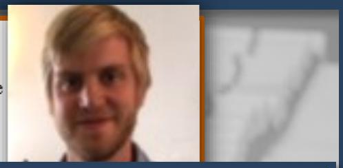

### Michael Reeks: Trace and Center of the Twisted Heisenberg Category

*Advisor: Weiqiang Wang*

The most common method of decategorification is taking the Grothendieck group - for example, the Khovanov-Lauda-Rouquier $2$-category was constructed so that its Grothendieck group is isomorphic to the idempotent form of a quantum group. However, applying alternative decategorification functors can reveal additional structure encoded by categorifications. Applying one such functor, the trace, to the KLR $2$-category gives the current algebra $\mathcal{U}(\mathfrak{g}[t])$, and taking the trace of the cyclotomic versions yields important representations of $\mathcal{U}(\mathfrak{g}[t])$ called local and global Weyl modules.  
Another important example of a categorification is Khovanov’s Heisenberg category, which is rich in representation theoretic and algebra-combinatorial information. Its Grothendieck group contains (and is conjecturally equal to) the Heisenberg algebra. However, the trace contains much more structure: it is isomorphic to the Lie algebra of differential operators on the circle, $W_{1+\infty}$, at level one. This is a large and rich algebra which contains the Heisenberg algebra. Another decategorification functor, the center, gives an algebra of shifted symmetric functions with connections to the asymptotic representation theory of symmetric groups.  
In this dissertation, we investigate the trace and center of a twisted version of the Heisenberg category, denoted $\mathcal{H}_{tw}$, which was introduced by Cautis and Sussan to categorify the twisted Heisenberg algebra. We establish a connection between the even trace of $\mathcal{H}_{tw}$ and a classical type of subalgebra $W^{-}$ of $W_{1+\infty}$ (which itself is a type A construction related to $\mathfrak{gl}_{\infty}$) introduced by Kac, Wang, and Yan.

**Theorem 10**. *The even trace of $\mathcal{H}_{tw}$ is isomorphic as an algebra to $W^{-}$ at level one.*

The center of $\mathcal{H}_{tw}$ is a polynomial algebra generated by closed curl diagrams, called bubbles. We show that this is in fact a subalgebra of the symmetric functions $\Lambda$.

**Theorem 11**. *The center of $\mathcal{H}_{tw}$ is isomorphic to the subalgebra $\Gamma \subset \Lambda$ generated by $\left\{p_{2n+1} \mid n \in \mathbb{N}\right\}$, where $p_{r}$ is the power-sum symmetric function.*

#### References

[1] C. Oğuz, M. Reeks, Trace of the twisted Heisenberg category, arXiv: 1702.08108.  
[2] H. Kvinge, C. Oğuz, M. Reeks, The center of the twisted Heisenberg category, factorial Schur Q-functions, and transition functions on the Schur graph, arXiv: 1712.09626.

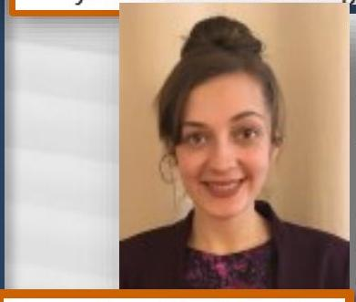

### Veronica Shalotenko: In Search of Bounds on the Dimension of $\operatorname{Ext}$ between Irreducible Modules for Finite Groups of Lie Type

*Advisor: Brian Parshall*

Let $q$ be a power of a prime $p$, and let $G(q)$ be a finite group of Lie type defined over $\mathbb{F}_{q}$. Let $k$ be an algebraically closed field of characteristic $r$. There are three distinct cases to consider in the representation theory of $kG(q)$: $r=0$ (the characteristic 0 case), $r=p$ (the defining characteristic case), and $r>0, r \neq p$ (the non-defining characteristic, or cross-characteristic, case).  
In defining and non-defining characteristic, we are interested in finding bounds on the dimension of cohomology groups $H^{i}(G(q), V)$, where $V$ is any irreducible $kG(q)$-module and $i \geq 1$ is fixed. In the defining characteristic, such bounds exist when the rank is fixed (this is due to Cline, Parshall, and Scott in the $i=1$ case and Bendel, Nakano, Parshall, Pillen, Scott, and Stewart in the $i>1$ case). In 2011, Guralnick and Tiep showed that 1-cohomology groups are bounded in non-defining characteristic.

**Theorem 12** (Guralnick and Tiep). *Suppose that $G(q)$ is a finite simple group of Lie type and $\operatorname{char}(k)=r>0$ with $r \neq p$. Let $W$ be the Weyl group of $G(q)$, and let $e$ be the Lie rank of $G(q)$. If $V$ is an irreducible $kG(q)$-module, then $\dim H^{1}(G(q), V) \leq \begin{cases}|W|+e & \text { if } V \text { is in the unipotent principal series, } \\ 1 & \text { otherwise. }\end{cases}$*

#### Some Generalizations of Guralnick and Tiep’s Theorem

Suppose that $G(q)$ has a split $BN$-pair of characteristic $p$ and that we are in the non-defining characteristic case (so, $\operatorname{char}(k)=r>0$ with $r \neq p$). We use techniques of modular Harish-Chandra theory to obtain the following bounds on the dimension of $\operatorname{Ext}^{1}$ between irreducible $kG(q)$-modules.

**Theorem 13** (Shalotenko). *If $Y$ and $V$ are irreducible $kG(q)$-modules in the unipotent principal series, then $\dim \operatorname{Ext}_{kG(q)}^{1}(Y, V) \leq|W|+\min (\dim Y, \dim V) e$.*

**Theorem 14** (Shalotenko). *Suppose that $G(q)=\mathrm{GL}_{n}(q)$, $\mathrm{SO}_{n}(q)$ with $n$ and $q$ odd, or $\mathrm{Sp}_{n}(q)$ with $n$ even and $q$ a power of 2. Let $\operatorname{char}(k)=r$ be a linear prime for $G(q)$. If $Y$ is a unipotent principal series representation and $V$ is an irreducible outside the unipotent principal series, then $\dim \operatorname{Ext}^{1}_{kG(q)}(Y, V) \leq\left[W: W_{J}\right]$, where $W_{J}$ is a parabolic subgroup of $W$ defined using the Harish-Chandra vertex of $V$.*

#### $\operatorname{Ext}$ Groups between Irreducible $k\mathrm{GL}_{n}(q)$-Modules

We also consider higher $\operatorname{Ext}$ groups in the case that $G(q)=\mathrm{GL}_{n}(q)$. In 1999, Cline, Parshall, and Scott related $H^{i}$ calculations for $\mathrm{GL}_{n}(q)$ (in non-defining characteristic) to $\operatorname{Ext}^{i}$ calculations over a $q$-Schur algebra. In this thesis, we generalize the results of CPS to relate certain $\operatorname{Ext}^{i}$ calculations over $\mathrm{GL}_{n}(q)$ (in non-defining characteristic) to $\operatorname{Ext}^{i}$ calculations over $S_{q}(n, n)$ (which, in turn, translate to $\operatorname{Ext}^{i}$ calculations over an appropriate quantum group).

### Jonathan Simone: Cut-and-Paste Operations and Exotic 4-Manifolds

*Advisor: Thomas Mark*

Since Milnor discovered the first pairs of manifolds that are homeomorphic but not diffeomorphic in 1956, simply connected smooth manifolds have been classified by purely algebraic tools in every dimension except dimension $4$. The goal of this research is to introduce a new technique of constructing exotic $4$-manifolds via the following cut-and-paste process: (1) locate a configuration of $2$-spheres $C$ embedded in an ambient $4$-manifold; (2) cut out a neighborhood of $C$ called a plumbing which can be described by a weighted graph; and (3) glue in its place a $4$-manifold with smaller homology. This technique generalizes the rational blow-down, an operation that has been successfully used to construct exotic $4$-manifolds. We begin with a heuristic definition.

**Definition 4**. A plumbing is $k$-replaceable if it can be “symplectically replaced” by a manifold with Euler characteristic $k$.

$1$-replaceable plumbings are precisely those that can be rationally blown down. Which plumbings are $2$-replaceable, you ask? Using Lisca’s classification of symplectic fillings of lens spaces and the theory of Lefschetz fibrations, we classify $2$-replaceable linear plumbings and construct $2$-replaceable plumbing trees. We then locate the $2$-replaceable plumbing depicted to the right in a blowup of $E(1)$ and "replace it" with its Euler characteristic $2$ symplectic replacement to obtain a $4$-manifold $X$. Using Freedman’s Theorem and Seiberg-Witten invariants, we prove the following.

**Theorem 15**. *$X$ is a symplectic exotic $\mathbb{C} P^{2} \# 6 \overline{\mathbb{C} P^{2}}$.*

With $1$- and $2$-replaceable plumbings understood, we explore the possible existence of $0$-replaceable plumbings (this exploration is still underway). First, we construct families of plumbings that can be smoothly replaced by rational homology $S^{1} \times D^{3}$s. Using such plumbings, it is routine to construct manifolds that are homeomorphic to well-known $4$-manifolds. For example, using the plumbing depicted to the right, we can construct a $4$-manifold that is homeomorphic to, but not

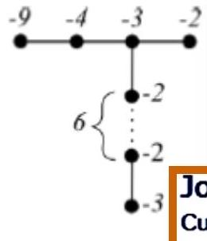

[figure not shown]

obviously diffeomorphic to, $\mathbb{C} P^{2} \# \overline{\mathbb{C} P^{2}}$. This would be the first example of an exotic $\mathbb{C} P^{2} \# \overline{\mathbb{C} P^{2}}$. To help determine whether these manifolds are indeed exotic, we can: (a) compute smooth $4$-manifold invariants; or (b) determine whether these manifolds

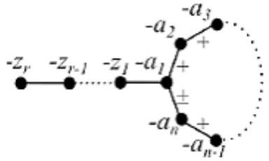

are symplectic. As a step towards (a), we prove a result that computes the Ozsváth-Szabó $4$-manifold invariant under certain conditions. Unfortunately, this theorem cannot be used to prove the particular example above is an exotic $\mathbb{C} P^{2} \# \overline{\mathbb{C}P}^{2}$ because the "certain conditions" are not satisfied. As a first step in exploring (b), we classify the tight contact structures with no Giroux torsion on the boundaries of the family of plumbings depicted to the left. This classification involves proving the following results, which is a generalization of an important result due to Lisca and Matic.

**Theorem 16**. *Suppose $(Y, \xi)$ is a contact $3$-manifold with nontrivial contact invariant $c(\xi,[\omega])$, for some $[\omega] \in H^{2}(Y ; \mathbb{R})$. Let $\left(W, J_{i}\right)$ be a Stein cobordism from $(Y, \xi)$ to $\left(\bar{Y}, \xi_{i}\right)$, for $i=1,2$. If the spin${}^{c}$ structures induced by $J_{1}$ and $J_{2}$ are not isomorphic, then $\xi_{1}$ and $\xi_{2}$ are nonisotopic tight contact structures.*

### Zachary Gates: Finite Presentability of Groups Acting on Locally Finite Twin Buildings

*Advisor: Peter Abramenko*

### Bradley Weaver: Non-Abelian Groups of Order Eight and the Local Lifting Problem

*Advisor: Andrew Obus*

## Congratulations to Our Graduate Teaching Award Winners!

### 2017-18 All-University Graduate Teaching Award

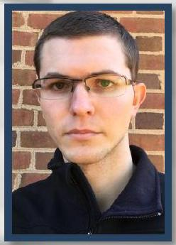

Mariano Echeverria

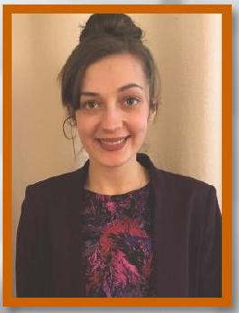

Veronica Shalotenko

### 2017-18 Department of Mathematics Outstanding Graduate Teaching Assistant Award

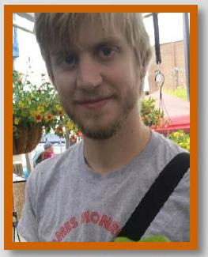

Michael Reeks

### 2017-18 Class of 1985 Fellowship for Creative Teaching Award

[figure not shown]

Zachary Gates

## Moon Duchin Speaks about Mathematics and Gerrymandering

By Sara Maloni

On March 21-22-23, 2018, Moon Duchin visited us, as the last speaker of the series "Math &...". Moon Duchin is an associate professor of Mathematics, a senior fellow in the Jonathan M. Tisch College of Civic Life, and the director of the Program in Science, Technology, and Society at Tufts University. Her pure math work is in geometry, topology, groups, and dynamics, and she is currently collaborating with civil rights organizers, coders, political scientists, lawyers, geographers, and philosophers on a large-scale project to detect and address gerrymandering.

On Thursday she gave a public talk titled "Mathematics of Gerrymandering: Geometry, Algorithms, and (Crimes Against)  
Democracy". After the talk, Moon was joined on stage by Brian Cannon (from OneVirginia2021) and Sally Hudson (from Frank Batten School of Leadership and Public Policy) who moderated the discussion between Moon and Brian. The  
event was very well attended. I think for all the participants from the Math Department it was exciting to see such interesting and important applications to problems we study in our research. On Friday, Moon joined Quantitative Collaborative and gave a talk titled "Data-Driven Approaches to Identifying a Gerrymander."

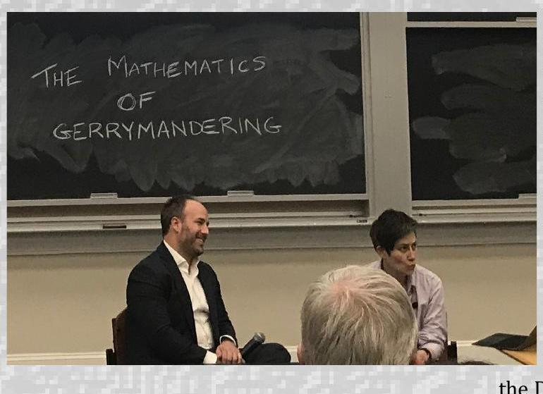

In her talk Moon pointed out that the power to draw boundary lines is often the power to control election outcomes, and hence the key question she wants to study is: how much skew is too much, and when should

the courts step in? Recently, some interventions from mathematics and computing have sprung on the redistricting scene, and they seem to hold a lot of promise. For example, at the beginning of the year the Pennsylvania Governor Tom Wolf asked Moon to aid him in coming up with nonpartisan Congressional district maps. Moon surveyed some geometric, statistical, and algorithmic approaches to identifying and addressing gerrymandering that have gotten traction in Wisconsin, North Carolina, and Pennsylvania. In particular, she explained how she used algorithmic sampling methods to explore the space of possible districting plans.

This visit was made possible by the generous help from the Arts & Science Diversity and Inclusion Grant, the Department of Mathematics, Department of Politics, Frank Batten School of Leadership and Public Policy, OneVirginia2021, and Quantitative Collaborative.

## The Problem Corner

1. Find all differentiable functions $f(x)$ on the real line such that $\left[f^{\prime}(x)\right]^{2}=4 f(x)$ and $f(-2)=f(2)=1$.
2. A microbe either splits into two perfect copies of itself or else disintegrates. If the probability of splitting is $p$, what is the probability that one microbe will produce an everlasting colony?
3. A game of solitaire is played as follows. After each play, according to the outcome, the player receives either $a$ or $b$ points, where $a$ and $b$ are positive integers and $a>b$. Their score accumulates from play to play. It is noticed that there are exactly 35 non-attainable scores and that one of those is 58. Find $a$ and $b$.
4. You are given 13 integers, all of them at least 1. They have the property that if we remove any one of them, you can divide the remaining 12 into two groups of 6 each such that the sum of those 6 are equal. Prove all thirteen numbers are the same.

What are you Doing?  
We’d like to hear from you!  
Email: math-newsletter@virginia.edu  
News & Events:  
http://math.virginia.edu/allnews/  
Department of Mathematics  
University of Virginia  
P. O. Box 400137

Charlottesville, VA 22904-4137